# Additional Exploratory Data Analysis

## Correlation

Below is a visual showing every variable and their correlations within the training data set (including only complete observations).

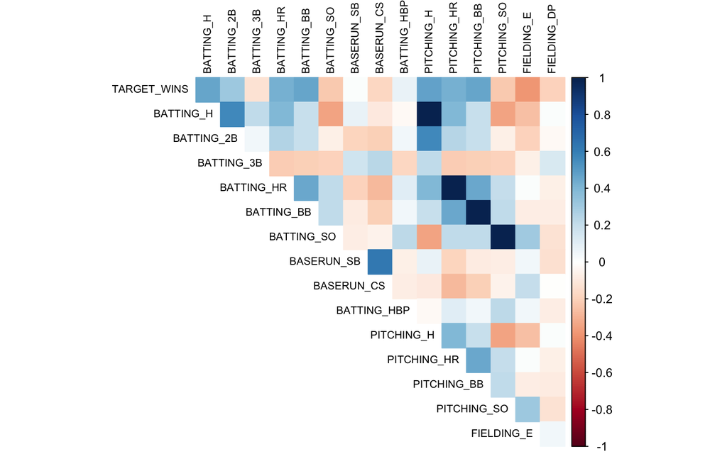

```r
train.cor <- training %>% select(-INDEX) %>% cor(., use = "complete.obs")
corrplot(train.cor, method="color",type="upper", tl.col="black", tl.cex = 0.7,
         diag=F)
```

```r
# Correlation with response variable specifically
data.frame(cor(training$TARGET_WINS, training, use="complete.obs")) %>%
  gather(key="Variable", value="Correlation",-INDEX) %>% select(-INDEX) %>%
  mutate(Correlation = cell_spec(round(Correlation,4),
                                 "html",
                                 color = ifelse(abs(Correlation) > .4,
                                                "red", "black"))) %>%
  kable(format = "html", escape=F) %>%
  kable_styling(full_width = F, position = "left") %>%
  add_header_above(c("Correlation with 'TARGET_WINS'"=2)) %>%
  footnote(general = "Red highlight indicates correlation > 0.4 (pos or neg).")
```

| Correlation with ‘TARGET_WINS’ Variable | Correlation with ‘TARGET_WINS’ Correlation |
| --- | --- |
| TARGET_WINS | 1 |
| BATTING_H | 0.4699 |
| BATTING_2B | 0.313 |
| BATTING_3B | -0.1243 |
| BATTING_HR | 0.4224 |
| BATTING_BB | 0.4687 |
| BATTING_SO | -0.2289 |
| BASERUN_SB | 0.0148 |
| BASERUN_CS | -0.1788 |
| BATTING_HBP | 0.0735 |
| PITCHING_H | 0.4712 |
| PITCHING_HR | 0.4225 |
| PITCHING_BB | 0.4684 |
| PITCHING_SO | -0.2294 |
| FIELDING_E | -0.3867 |
| FIELDING_DP | -0.1959 |

Note:  
Red highlight indicates correlation > 0.4 (pos or neg).

We see some correlation between a few explanatory variables and our target variable:

`BATTING_H`,`BATTING_HR`,`BATTING_BB`,`PITCHING_H`,`PITCHING_HR`, and `PITCHING_BB`.

However there is some correlation between them that we may have to account for:

[figure not shown]

```r
train.cor2 <- training %>%
  select(BATTING_H,BATTING_HR,BATTING_BB,PITCHING_H,PITCHING_HR,PITCHING_BB) %>%
  cor(., use = "complete.obs")

corrplot(train.cor2, method="color",type="lower", tl.col="black", tl.cex = 0.7,
         diag=F)
```

## Missing Data

Of the 2,276 observations in the training data set, only 191 are complete (no missing values in any variable). So, some imputation may be required to ensure we have enough training data to work with.

Looking at which variables are missing:

```r
# Get variable names
vars <- names(training)[3:17]
missing <- data.frame(variable=NA,missingVals=0)

for(i in 1:length(vars)){
  missing <- rbind(missing,
                   data.frame(variable = paste(vars[i]),
                              missingVals = sum(is.na(training[,paste(vars[i])])))
                  )
}

missing %>% filter(!is.na(variable)) %>%
  select(`Variable Name` = variable,
         `# Missing Values` = missingVals) %>%
  arrange(-`# Missing Values`) %>% kable()
```

| Variable Name | # Missing Values |
| --- | --- |
| BATTING_HBP | 2085 |
| BASERUN_CS | 772 |
| FIELDING_DP | 286 |
| BASERUN_SB | 131 |
| BATTING_SO | 102 |
| PITCHING_SO | 102 |
| BATTING_H | 0 |
| BATTING_2B | 0 |
| BATTING_3B | 0 |
| BATTING_HR | 0 |
| BATTING_BB | 0 |
| PITCHING_H | 0 |
| PITCHING_HR | 0 |
| PITCHING_BB | 0 |
| FIELDING_E | 0 |

We see that `BATTING_HBP`, `BASERUN_CS`, `FIELDING_DP`, and `BASERUN_SB` have the most missing values. None of those variables were well correlated with our outcome variable so maybe it is ok to leave them alone.

Next we have `BATTING_SO` and `PITCHING_SO`. These variables had correlations close to 0.22. So, if we plan on using those in our model, we may want to exclude those cases where they are missing (which leaves us approximately 2,174 complete observations).

Critical Thinking Group 3

2019-09-14